# HSS8005 Stream C: Introduction to Quantitative Linguistics

## Overview

This course is:

- an introduction to analysing large-scale linguistic data sets in R
- aimed at linguists working with quantitative data
- mainly going to focus on phonetic, sociolinguistic and reaction time datasets, but the principles can be applied to any subfield of any kind

## What this course is *not*

- An introduction to Natural Language Processing
- An introduction to corpus linguistics
- Discourse analysis, sentiment analysis etc.

## Schedule

- Today: Intro to course and to R
- Thursday: Data visualisation
- Next Tuesday: Basic statistical tests
- Next Thursday: Data wrangling, advanced visualisation, statistical tests and requests!

## What is your research?

- Who are you and what do you want to analyse?
- What is your dependent variable?
- What about independent variables?

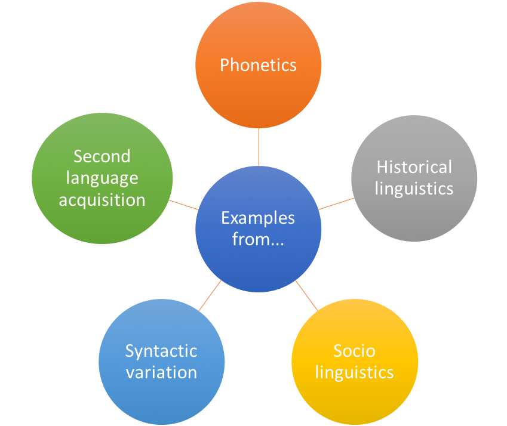

## Introduction to R

## Why use R?

- R is the statistics software paradigm of our day
- It's free!
- It's platform independent
- Packages for everything (constantly being updated)
- All the cool kids use it

## This lesson's goals

- Work with an R notebook (simpler than working with R proper for now)
- Read in and manipulate data
- Make some figures

## R can be used as a calculator

## The difference between R and RStudio…

**"RStudio is like an Instagram filter over R, to make your R user experience better."** - Joe Fruehwald ([R course](https://jofrhwld.github.io/teaching/courses/2017_lsa/))

- Check out Joe's [Workshop](https://blogs.ncl.ac.uk/ncllingconf/workshops/) at this year's Newcastle Postgraduate Conference in Linguistics

[figure not shown]

[figure not shown]

## Why are we using R?

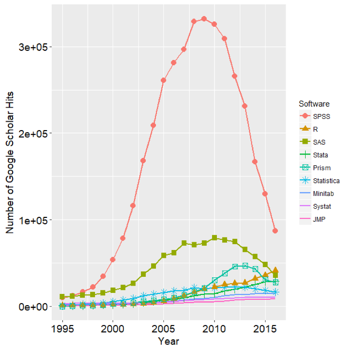

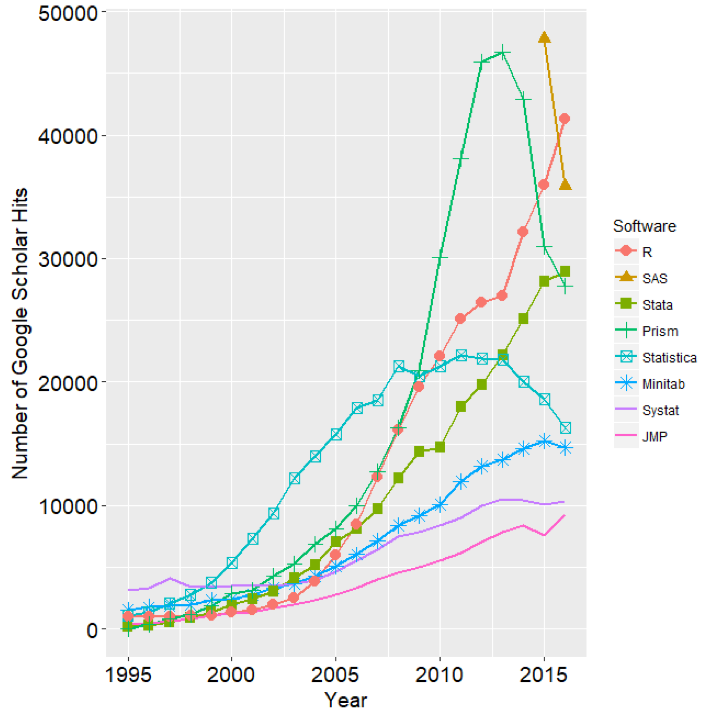

The trend of SPSS and R based on Google Scholar articles

## Data files

- Need to be `.csv` or `.txt` NOT Excel
- Need to have one token per row

## Bad data formatting for R

- Never organise your data like this:

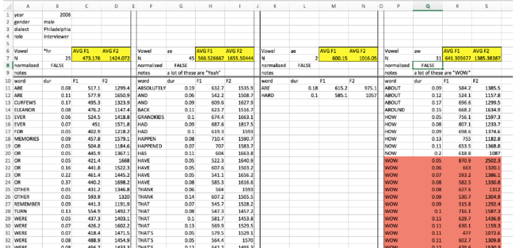

## General tips

- R is case sensitive (it will treat an `s` as a completely different character to `S`)
- Don't use spaces in your filenames and folders
- Softwrap your code by going to **Tools > Global Options > Code** and ticking **Soft-wrap R source files**.

## Factors and levels: `factors`

Our variables are called **factors** in R terminology.

[output not shown]

[output not shown]

## Factors and levels: `factor levels`

Our variables are called **factors** in R terminology. Each option for a factor is a **factor level**.

```
## [1] "don't rhyme" "rhyme"
```

## Simple functions: `head` and `tail`, `dim`

```
##      sex               occupation age age_group
## 1 female                  Teacher  32     young
## 2 female Government Administrator  47    middle
## 3   male    Management Consultant  61       old
## 4 female                  student  19     young
## 5   male               Accountant  34     young
## 6   male                  Retired  63       old
##                                    town postcode_birth postcode_now bread
## 1 Bishopton, Renfrewshire, Scotland, UK            PA7         2021  roll
## 2                             Dumbarton            G82         AB22  roll
## 3                              EDNBURGH           EH15          AL2  roll
## 4                                 wigan            WA3           B5  barm
## 5                Bellshill\nAtherstone             CV9          B79  roll
## 6                               Bristol            BS8         BA12  roll
##   furniture clothing evening_meal   group  foot_strut    for_more
```

[output cut: 90 more lines]

```
##         sex       occupation age age_group                            town
## 6591 female      hairdresser  31     young     Germany. Catterick and york
## 6592   male       IT Manager  45    middle Newton Aycliffe, County Durham.
## 6593   male         Engineer  45    middle                       Sheffield
## 6594   male Radio technician  30     young            South Molton (Devon)
## 6595 female          Student  19     young           Ashbourne, Derbyshire
## 6596 female          Student  18     young                 Sale, Cheshire
##      postcode_birth postcode_now          bread furniture clothing
## 6591           YO10          YO8           roll      sofa trousers
## 6592            DL5          YO8            bun      sofa trousers
## 6593            S31          YO8            bun      sofa trousers
## 6594           EX36          BH9           roll      sofa trousers
## 6595        DE6 1JF          DE6 bun, cob, roll      sofa trousers
## 6596            M33         CW11           barm    settee trousers
##                               evening_meal    group  foot_strut for_more
```

[output cut: 76 more lines]

## Simple functions: `dim` and `colnames`

```
## [1] 6596   34
```

```
##  [1] "sex"            "occupation"     "age"            "age_group"
##  [5] "town"           "postcode_birth" "postcode_now"   "bread"
##  [9] "furniture"      "clothing"       "evening_meal"   "group"
## [13] "foot_strut"     "for_more"       "one_gone"       "book_spook"
## [17] "fur_bear"       "sauce_source"   "pour_poor"      "eight_ate"
## [21] "bangor_banger"  "mute_moot"      "spa_spar"       "thin_fin"
## [25] "give_it_me"     "I_done_it"      "it_was"         "you_was"
## [29] "beaches_was"    "I_werent"       "they_was"       "we_was"
## [33] "dress_what"     "things_what"
```

## Download the materials for today's class here

## Packages

- What are packages?
- The first time you use them, you will need to install the packages (you only need to do this once)

```r
install.packages("dplyr")
install.packages("ggplot2")
```

- Load the packages

```r
library(dplyr)
library(ggplot2)
```